# R Notebook

```r
library(rtweet)
library(readr)
library(tidyverse)
library(dplyr)
library(stringr)
```

Load the code_clan_tweets.csv data. Find the number of rows, columns, and list all the variable names

```r
code_clan_tweets <- read_csv("data/code_clan_tweets.csv")
```

```r
dim(code_clan_tweets)
```

```
[1] 234  27
```

```r
names(code_clan_tweets)
```

```
 [1] "tweet_id"               "user_id"                "created_at"             "screen_name"
 [5] "text"                   "source"                 "display_text_width"     "reply_to_status_id"
 [9] "reply_to_user_id"       "reply_to_screen_name"   "is_quote"               "is_retweet"
[13] "favorite_count"         "retweet_count"          "quote_count"            "reply_count"
[17] "hashtags"               "symbols"                "urls_url"               "urls_t.co"
[21] "urls_expanded_url"      "media_type"             "retweet_source"         "retweet_favorite_count"
[25] "retweet_retweet_count"  "retweet_user_id"        "retweet_location"
```

Q2. First, we’re going to summarise the number of likes (favorite_count) CodeClan tweets have. Create a boxplot to check for outliers.

```r
favorite_count_tweet <- summary(code_clan_tweets$favorite_count)

favorite_count
```

[output not shown]

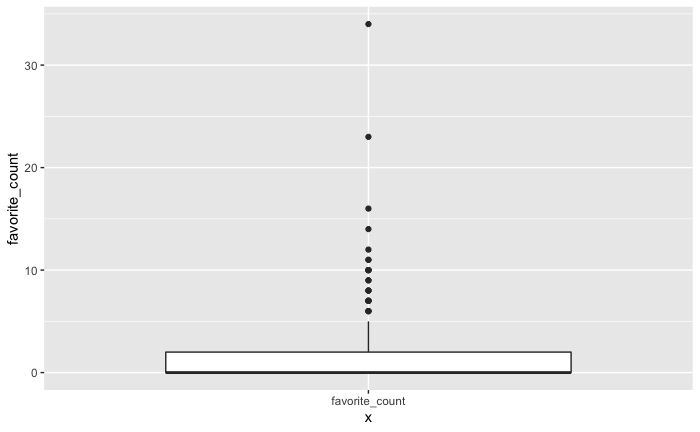

```r
ggplot(code_clan_tweets, aes(x = "favorite_count", favorite_count)) +
  geom_boxplot()
```

3. Find the total number of favourited tweets (stored in favorite_count) that CodeClan tweets have got. Don’t add a tweet’s favorite_count to the total when the tweet was quoted (see the is_quote variable).

```r
code_clan_tweets %>%
  filter(is_quote == FALSE) %>%
  summarise(total = sum(favorite_count))
```

| total |
| --- |
| 425 |

```r
NA
NA
NA
```

Q4. Summarise the mean number of retweets (retweet_count), split by the type of platform that was used to tweet (source). Again, omit quoted tweets from the mean.

```r
code_clan_tweets %>%
  filter(is_quote == FALSE) %>%
  group_by(source) %>%
  summarise(average_retweet = mean(retweet_count))
```

| source | average_retweet |
| --- | --- |
| Hootsuite Inc. | 1.428571 |
| Tweetbot for Mac | 4.000000 |
| TweetDeck | 5.000000 |
| Twitter for iPhone | 3.051948 |
| Twitter Web App | 2.478632 |
| Twitter Web Client | 2.000000 |

```r
NA
```

Q5.

Count the total number of likes (i.e. total of favorite_count), split by media type, and arrange them from most likes to least. Assume that any tweets without a listed media type are of type “text”.

```r
code_clan_tweets %>%
  mutate(media_type2 = replace_na(media_type, "text")) %>%
  group_by(media_type2) %>%
  summarise(favourite_count_total = sum(favorite_count)) %>%
  arrange(desc(favourite_count_total))
```

| media_type2 | favourite_count_total |
| --- | --- |
| photo | 371 |
| text | 75 |

```r
NA
```

Q6. Find the mean number of characters that a CodeClan tweet contains.

```r
code_clan_tweets %>%
  summarise(avg_tweet_lenght = mean(display_text_width))
```

| avg_tweet_lenght |
| --- |
| 149.4188 |

```r
NA
NA
NA
```

Q7. The code_clan_info.csv data file contains status_url along with other info. Load this in, and join it to the code_clan_tweets tibble, so that you have a status_url for each tweet. Decide which variable to join the tibbles on.

```r
code_clan_info <- read_csv("data/code_clan_info.csv")
```

```r
names(code_clan_info)
```

```
 [1] "tweet_id"           "status_url"         "name"               "location"           "description"
 [6] "url"                "protected"          "followers_count"    "friends_count"      "listed_count"
[11] "statuses_count"     "favourites_count"   "account_created_at" "verified"           "profile_url"
```

```r
codeclan_all <- left_join(code_clan_tweets,code_clan_info, by = "tweet_id")
```

```r
# 8 : create a variable which has all the hashtags in lowercase for analysis


codeclan_hashtags <- codeclan_all%>%
  select(tweet_id, hashtags) %>%
  mutate(lowcase_hashtag = str_to_lower(hashtags)) %>%
  select(-hashtags) %>%
  drop_na(lowcase_hashtag)

codeclan_hashtags
```

| tweet_id | lowcase_hashtag |
| --- | --- |
| 345 | dundee |
| 344 | tech |
| 342 | techmums |
| 341 | techmums |
| 340 | techmums |
| 336 | techmums |
| 335 | forensicshoeprints |
| 332 | forensicshoeprints |
| 331 | forensicshoeprints |
| 329 | inverness |

[output cut: 107 more lines]

```r
NA
NA
```